# Monday Lecture: Mapping

Ruth Vergara Reyes

3/8/2021

# Introduction

Today we will be learning how to map data onto a world map.

# Load Libraries

```r
library(tidyverse)
library(here)
library(maps)
library(mapdata)
library(mapproj)
```

# Load Data

```r
# Read in data on population in California by county
popdata<-read_csv(here("Week_7","data","CApopdata.csv"))

#read in data on number of seastars at different field sites
stars<-read_csv(here("Week_7","data","stars.csv"))
```

# Packages we can use

**map_data(“location”)** is the function we use to pull whatever base layer we want in the map

```r
world <- map_data("world")

head(world)
```

```
##        long      lat group order region subregion
## 1 -69.89912 12.45200     1     1  Aruba      <NA>
## 2 -69.89571 12.42300     1     2  Aruba      <NA>
## 3 -69.94219 12.43853     1     3  Aruba      <NA>
## 4 -70.00415 12.50049     1     4  Aruba      <NA>
## 5 -70.06612 12.54697     1     5  Aruba      <NA>
## 6 -70.05088 12.59707     1     6  Aruba      <NA>
```

## We can get a map for just the United States of America

```r
usa <- map_data("usa")

head(usa)
```

```
##        long      lat group order region subregion
## 1 -101.4078 29.74224     1     1   main      <NA>
## 2 -101.3906 29.74224     1     2   main      <NA>
## 3 -101.3620 29.65056     1     3   main      <NA>
## 4 -101.3505 29.63911     1     4   main      <NA>
## 5 -101.3219 29.63338     1     5   main      <NA>
## 6 -101.3047 29.64484     1     6   main      <NA>
```

## We can also get maps of different countries in the world.

```r
## For example Italy
italy <- map_data("italy")

head(italy)
```

```
##       long      lat group order        region subregion
## 1 11.83295 46.50011     1     1 Bolzano-Bozen      <NA>
## 2 11.81089 46.52784     1     2 Bolzano-Bozen      <NA>
## 3 11.73068 46.51890     1     3 Bolzano-Bozen      <NA>
## 4 11.69115 46.52257     1     4 Bolzano-Bozen      <NA>
## 5 11.65041 46.50721     1     5 Bolzano-Bozen      <NA>
## 6 11.63282 46.48045     1     6 Bolzano-Bozen      <NA>
```

## We can get data and different resolutions for states in the USA by using:

```r
state <- map_data("state")

head(state)
```

```
##        long      lat group order  region subregion
## 1 -87.46201 30.38968     1     1 alabama      <NA>
## 2 -87.48493 30.37249     1     2 alabama      <NA>
## 3 -87.52503 30.37249     1     3 alabama      <NA>
## 4 -87.53076 30.33239     1     4 alabama      <NA>
## 5 -87.57087 30.32665     1     5 alabama      <NA>
## 6 -87.58806 30.32665     1     6 alabama      <NA>
```

## We can also get the data and differ. resolutions for different counties in the USA by using:

```r
counties <- map_data("county")

head(counties)
```

```
##        long      lat group order  region subregion
## 1 -86.50517 32.34920     1     1 alabama   autauga
## 2 -86.53382 32.35493     1     2 alabama   autauga
## 3 -86.54527 32.36639     1     3 alabama   autauga
## 4 -86.55673 32.37785     1     4 alabama   autauga
## 5 -86.57966 32.38357     1     5 alabama   autauga
## 6 -86.59111 32.37785     1     6 alabama   autauga
```

# Structure of the data

- **long** is longitude. Things to the west of the prime meridian are negative.
- **lat** is latitude.
- **order** shows in which order ggplot should “connect the dots”
- ***region and subregion** tell what region or subregion a set of points surrounds.
- **group.** This is very important! ggplot2’s functions can take a group argument which controls (amongst other things) whether adjacent points should be connected by lines. If they are in the same group, then they get connected, but if they are in different groups then they don’t. Essentially, having to points in different groups means that ggplot “lifts the pen” when going between them.

# Making a map of the world

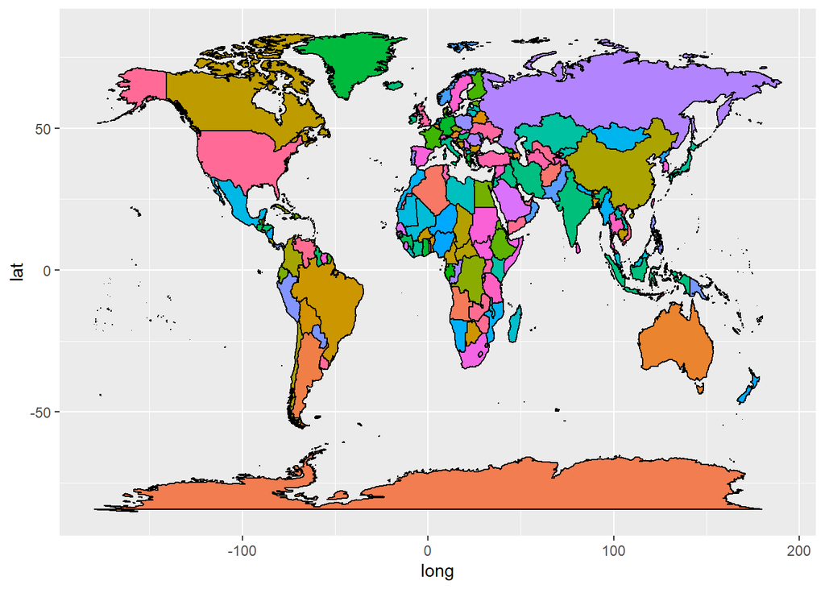

```r
ggplot()+
  geom_polygon(data = world,
               aes(x = long,
                   y = lat,
                   group = group,
                   fill = region),      ### How we got each country to be colored ##
               color = "black")+
  guides(fill = FALSE)                  ### How we got rid of legend ##
```

### This is what happens when we forget **group = group**

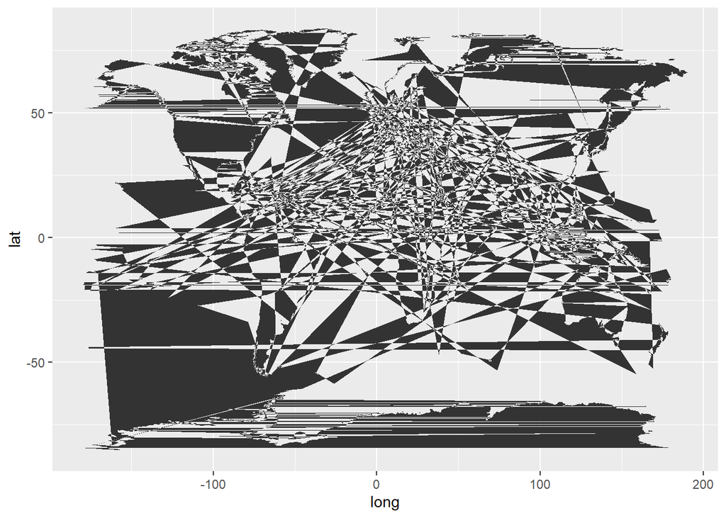

```r
ggplot()+
  geom_polygon(data = world, aes(x = long, y = lat))
```

### Changing the Visuals

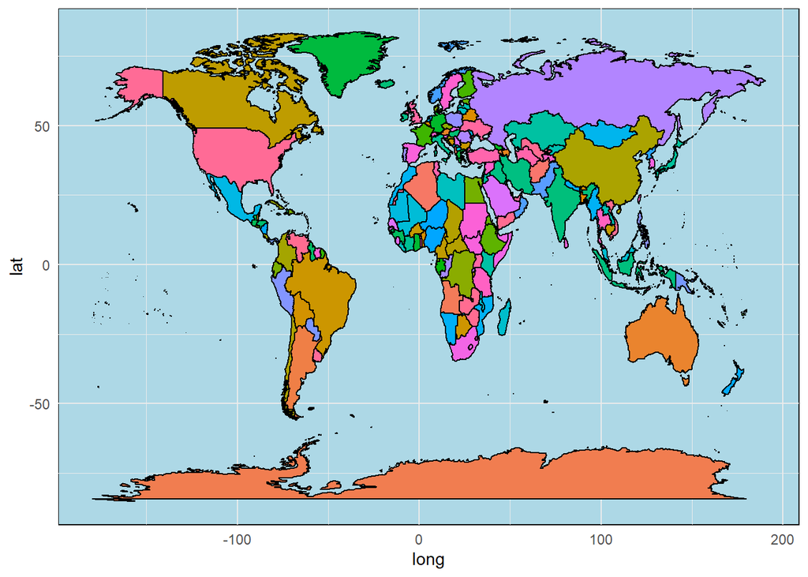

```r
ggplot()+
  geom_polygon(data = world,
               aes(x = long,
                   y = lat,
                   group = group,
                   fill = region),
               color = "black")+
  theme_minimal()+
  guides(fill = FALSE)+
  theme(panel.background = element_rect(fill = "lightblue"))   ### How we got the water(ocean) to be blue ##
```

### Changing the Map Projection

what we are changing: *coord_map(projection **" "**, xlim = c(**’ - ’**))*

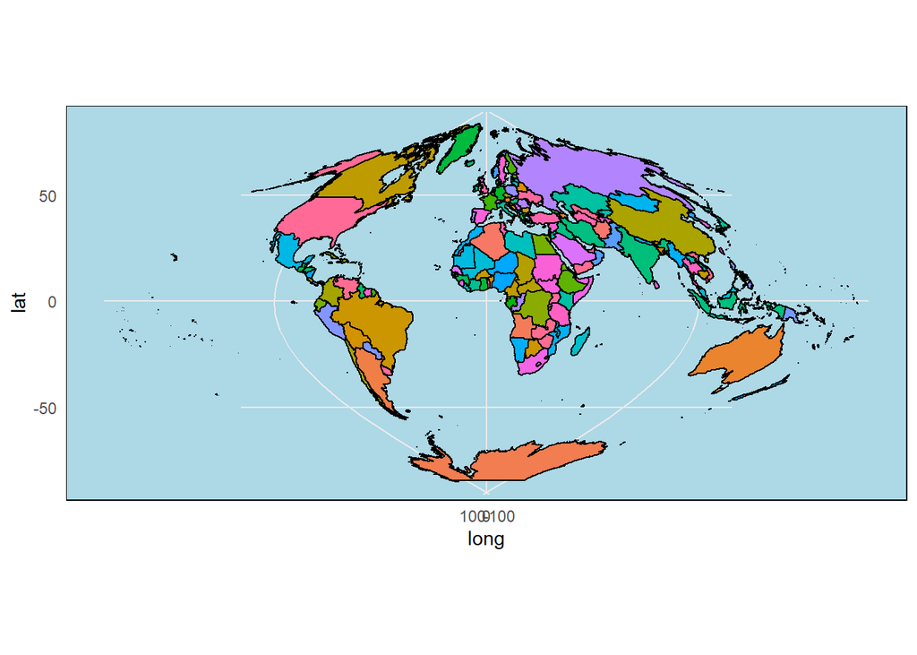

```r
ggplot()+
  geom_polygon(data = world,
               aes(x = long,
                   y = lat,
                   group = group,
                   fill = region),
               color = "black")+
  theme_minimal()+
  guides(fill = FALSE)+
  theme(panel.background = element_rect(fill = "lightblue"))+
  coord_map(projection = "sinusoidal",      ### Whatever is in the " " is what we change ###
            xlim = c(-180,180))             ### The numbers is what we can change ##
```

# California Map

The following is a map of the different counties in CA.

### Cleaning up the data

```r
head(state)                          ### Using state data ##
```

```
##        long      lat group order  region subregion
## 1 -87.46201 30.38968     1     1 alabama      <NA>
## 2 -87.48493 30.37249     1     2 alabama      <NA>
## 3 -87.52503 30.37249     1     3 alabama      <NA>
## 4 -87.53076 30.33239     1     4 alabama      <NA>
## 5 -87.57087 30.32665     1     5 alabama      <NA>
## 6 -87.58806 30.32665     1     6 alabama      <NA>
```

```r
CA_data <- state %>%
  filter(region == "california")     ### Filtering to get CA data only ##

head(counties)[1:3,]                 ### only showing the first 3 rows for space
```

```
##        long      lat group order  region subregion
## 1 -86.50517 32.34920     1     1 alabama   autauga
## 2 -86.53382 32.35493     1     2 alabama   autauga
## 3 -86.54527 32.36639     1     3 alabama   autauga
```

```r
head(popdata)
```

```
## # A tibble: 6 x 2
##   County         Population
##   <chr>               <dbl>
## 1 los angeles      10081570
## 2 san diego         3316073
## 3 orange            3168044
## 4 riverside         2411439
## 5 san bernardino    2149031
## 6 santa clara       1927470
```

```r
CApop_county<-popdata %>%
  select("subregion" = County, Population)  %>% # rename the county col
  inner_join(counties) %>%
  filter(region == "california")     ### some counties have same names in other states

head(CApop_county)
```

```
## # A tibble: 6 x 7
##   subregion   Population  long   lat group order region
##   <chr>            <dbl> <dbl> <dbl> <dbl> <int> <chr>
## 1 los angeles   10081570 -119.  34.8   175  7827 california
## 2 los angeles   10081570 -118.  34.8   175  7828 california
## 3 los angeles   10081570 -118.  34.8   175  7829 california
## 4 los angeles   10081570 -118.  34.6   175  7830 california
## 5 los angeles   10081570 -118.  34.6   175  7831 california
## 6 los angeles   10081570 -118.  34.5   175  7832 california
```

### Mapping the Data

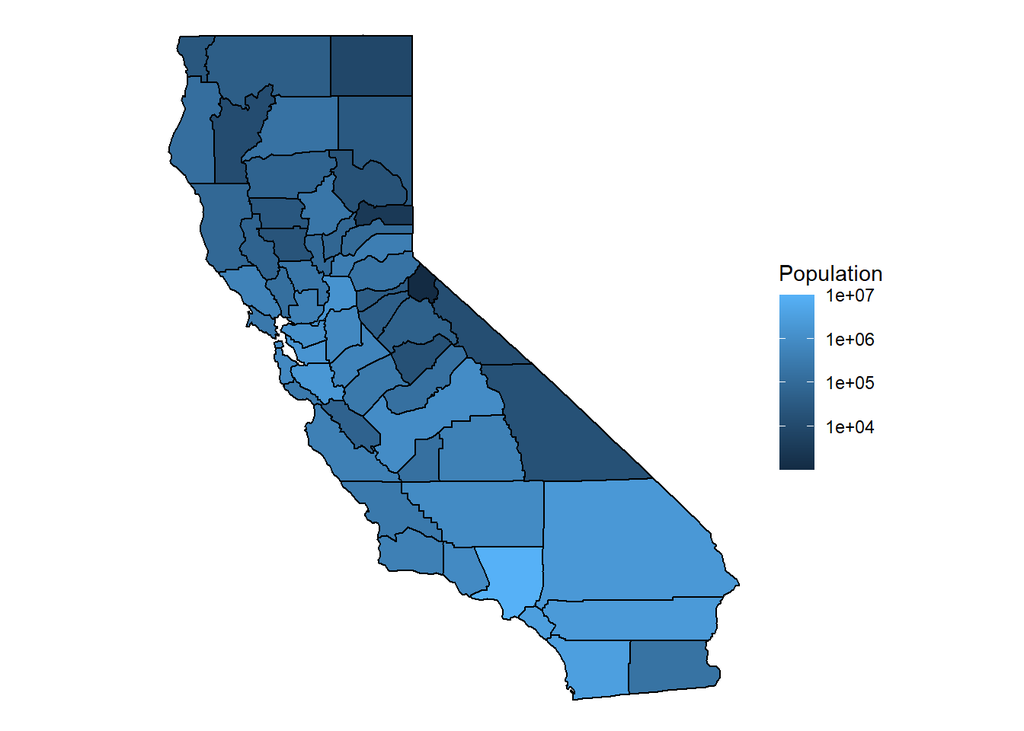

```r
ggplot()+
  geom_polygon(data = CApop_county,         ### Data we will use ##
               aes(x = long,
                   y = lat,
                   group = group,
                   fill = Population),
               color = "black")+
  theme_void()+
  coord_map()+
  scale_fill_gradient(trans = "log10")      ### Color scale ##
```

### Adding a layer of points

```r
head(stars)
```

```
## # A tibble: 6 x 3
##     lat  long star_no
##   <dbl> <dbl>   <dbl>
## 1  33.5 -118.      10
## 2  35.5 -121.       1
## 3  39.5 -124.      25
## 4  32.9 -117.      22
## 5  33.5 -118.       8
## 6  33.5 -118.       3
```

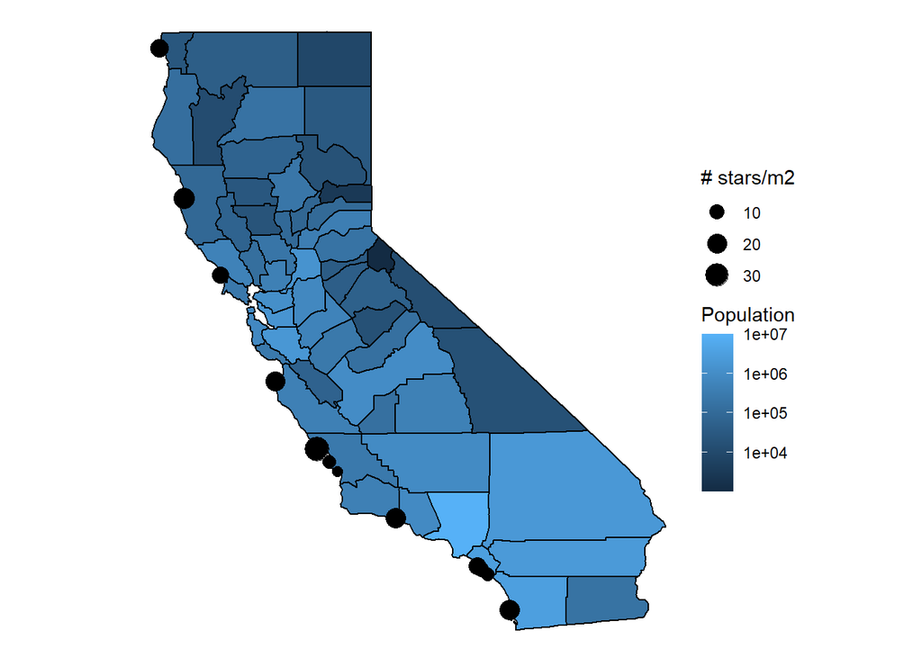

```r
ggplot()+
geom_polygon(data = CApop_county,
             aes(x = long,
                 y = lat,
                 group = group,
                 fill = Population),
             color = "black")+
  geom_point(data = stars,                     ### add a point at all my sites ##
             aes(x = long,
                 y = lat,
                 size = star_no))+
  coord_map()+
  theme_void() +
  scale_fill_gradient(trans = "log10")+
  labs(size = "# stars/m2") +
  ggsave(here("week_7","output","CApop.pdf"))  ### How we save the image ##
```